# Part II - (Airline On-Time Performance)

## by (Eloebhose Kingsley Osazele)

## Investigation Overview

**In this investigation , I was Interested in finding out about:**

- What major factors are causing flights arrival and departure delay?
- Is distance a major determinants of delayed flights?
- Are flights delay due to the unique carriers?
- Are they any other interesting patterns that affected delayed flights?

## (Departure Delay)

The main object of the Airline Ontime Performance project was to know the major causes of the delays. So first of all we need to know how many percent of flights were delayed and what is their value. This is shown using a barchart and a pie chart.

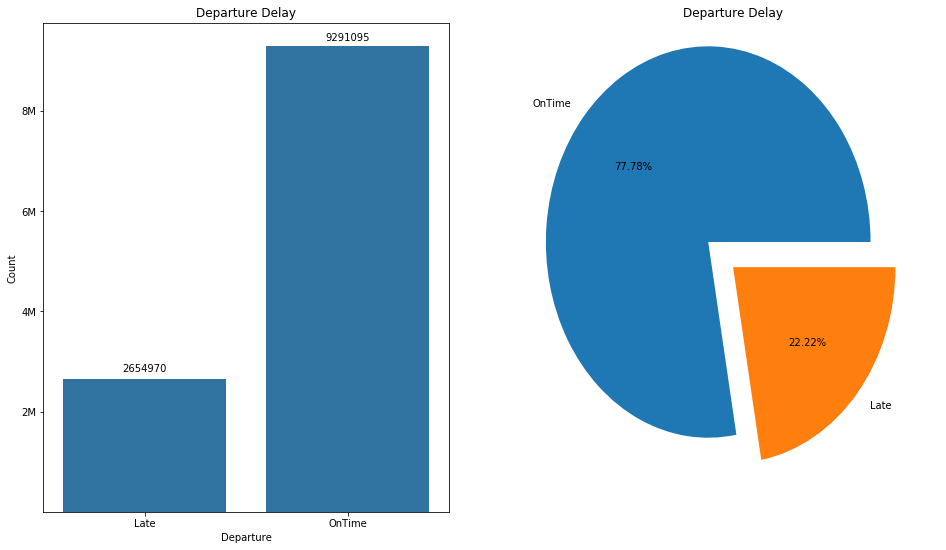

## (Arrival Delay)

The main object of the Airline Ontime Performance project was to know the major causes of the delays. So we need to also know how many percent of flights had arrival delay greater than 15 minutes(Late) and how many flights had arrival delay less than 15 minutes(OnTime) and what is their value. This is shown using a barchart and a pie chart.

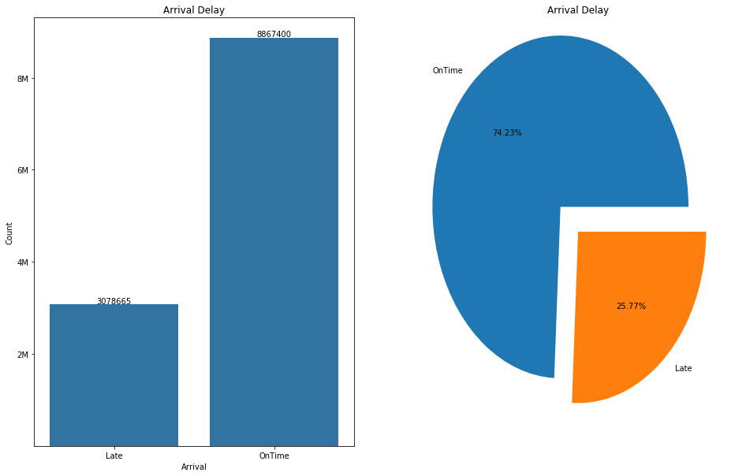

## (Reasons For Delay)

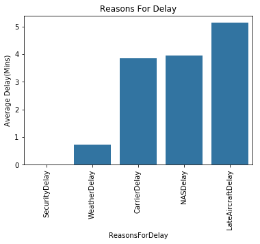

## (Average Arrival Delay of Airlines)

Next, let us see the Average Arrival Delay of each Airlines for the year 2008.

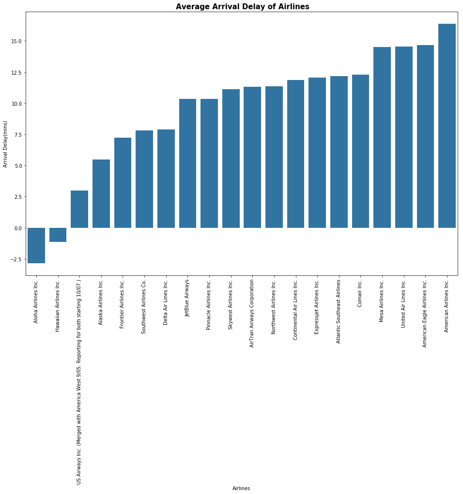

## (Average Departure Delay of Airlines)

Next, let us see the Average Departure Delay of each Airlines for the year 2008.

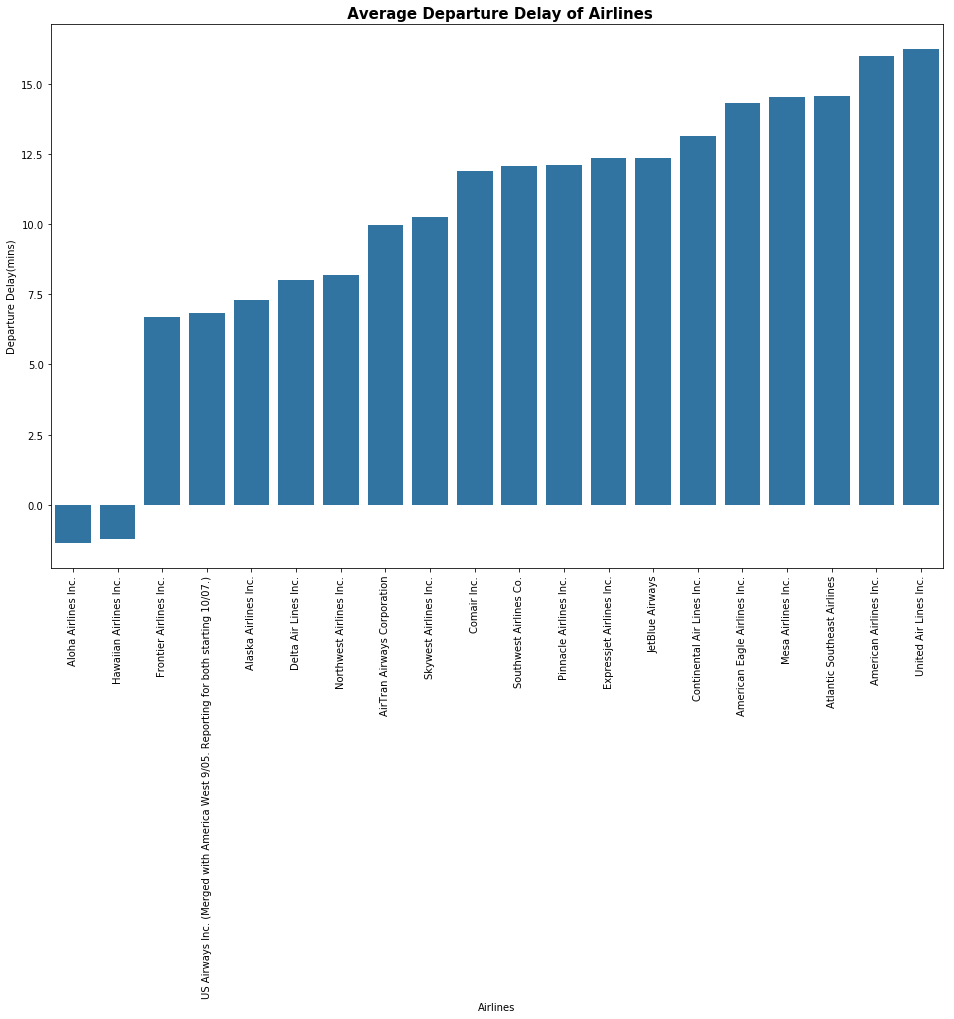

## (Reasons For Delay For United Airlines and American Airlines inc)

After using the Adapted bar chart to investigate the relation between Airlines and Arrival and Departure Delay variables, we decided to look futher into the reasons for United Airlines inc. and American Airlines inc having delayed flights.

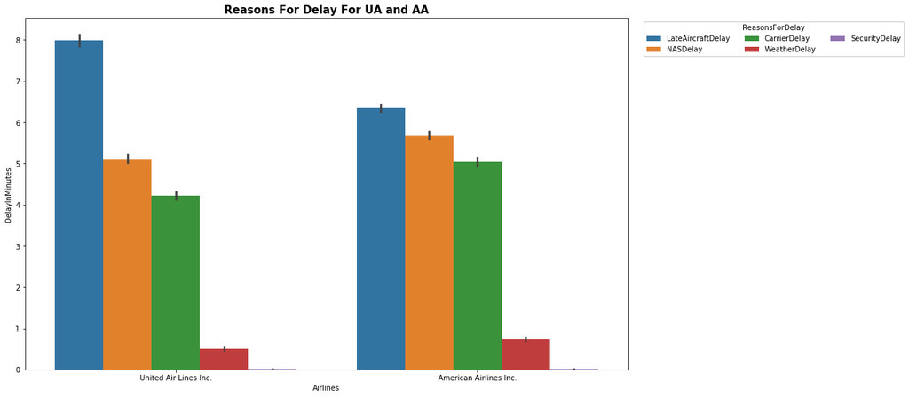